# Paired Treatment Pathway Response Report

Treated vs Untreated pathways, interpreted against the Yu2021 healthy reference

Published

July 15, 2026

# How to read this report

Every pathway shown here passed one filter only: **statistically significant in the paired `Treated vs Untreated` comparison** (FDR ≤ 0.05). That comparison is the sole basis for inclusion and for statistical inference.

The Yu2021 healthy cohort is not part of that statistical test. It’s used purely as an **external directional reference** — an independent dataset that tells us roughly what “looks healthy” for a given pathway, so we can ask whether the treatment effect we already found to be significant moves a pathway *toward* or *away from* that reference.

| Untreated vs Healthy | Treated vs Untreated | Interpretation |
| --- | --- | --- |
| NES > 0 (elevated in disease) | NES < 0 (treatment decreases it) | **Suppressed by treatment** — disease-high pathway pulled down |
| NES < 0 (depleted in disease) | NES > 0 (treatment increases it) | **Restored by treatment** — disease-low pathway brought back up |
| NES > 0 | NES > 0 | Disease-high pathway pushed **further up** |
| NES < 0 | NES < 0 | Disease-low pathway pushed **further down** |
| not available | — | No external reference; treatment effect only |

**Direction, not destination**

The interpretation labels above (e.g. “restored by treatment”) are based **only on sign**: did the paired treatment effect move a pathway toward healthy? They say nothing about how close it got. `Treated vs Healthy` is also an independent, unpaired comparison against a small reference cohort (2 donors), so short arrows can still reflect a real, statistically robust paired effect — they just haven’t been benchmarked against an absolute “healthy” cutoff, because the data don’t support drawing one reliably. The paired `Treated vs Untreated` NES and FDR (visible in the table and quadrant plot below) are the rigorously tested quantities; treat the trajectory plot as showing direction of movement, not proximity to normal.

Report scope

| Metric | Value |
| --- | --- |
| Paired-significant pathway x celltype x database rows | 10,112 |
| Distinct cell types | 18 |
| Distinct pathway databases | 3 |
| Paired FDR cutoff used for inclusion | 0.05 |

# Overall pattern: toward vs. away from healthy

For each cell type, what fraction of its paired-significant pathways move toward the external healthy reference versus further away from it?

[interactive chart not shown]

# Pathway trajectories: disease state → treatment effect

This is the most direct view of the question this analysis is asking. For each paired-significant pathway, the **open circle** marks its position in `Untreated vs Healthy` (how abnormal it was before treatment) and the **filled, colored point** marks `Treated vs Healthy` (where it ended up after treatment). The arrow shows the movement treatment caused. The dashed line at zero is the healthy reference itself.

Only the top 15 pathways per cell type (ranked by paired `Treated vs Untreated` FDR) are shown, to keep each panel readable.

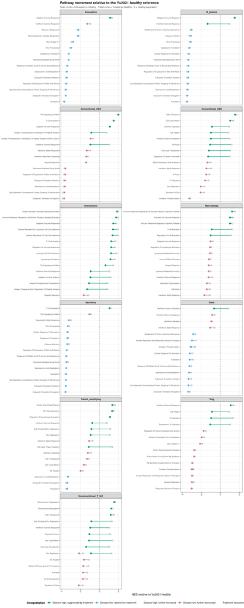

# Quadrant view: treatment effect vs. baseline disease direction

The same paired-significant pathways, plotted by their raw disease direction (`Untreated vs Healthy`, x-axis) against the paired treatment effect (`Treated vs Untreated`, y-axis). Point size reflects paired-treatment significance strength. The 5 strongest pathways in each quadrant (by paired FDR) are labeled.

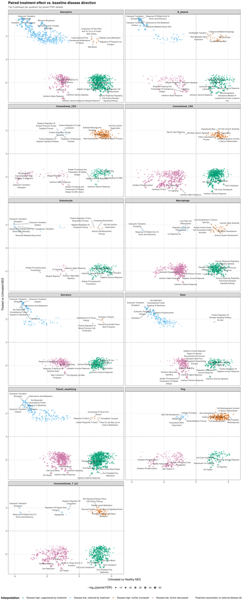

# Strongest hits across all cell types

The top 40 paired-significant pathways overall, ranked by paired FDR, shown across all three contrasts for direct comparison.

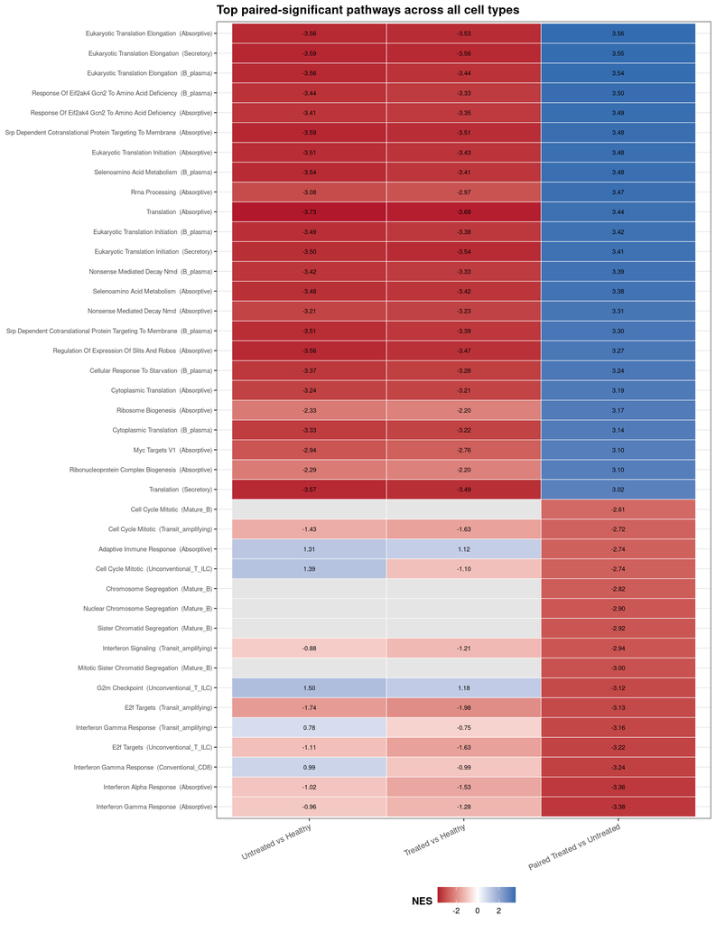

# Statistical Tests: Could This Pattern Be Random?

Interferon/cytokine pathways showing up repeatedly, across many independent cell types, in the direction expected for a JAK inhibitor is a striking pattern — but “striking” isn’t a statistic. Two independent tests below formalize the question: is this cluster of hits more concentrated in JAK-STAT-adjacent pathways, and more recurrent across cell types, than would be expected if paired-significant hits were scattered randomly across the tested pathway universe?

**The expected signature is broader than “interferon” alone**

The cross-cell-type recurrence results (Test 2) surfaced two related but distinct signals recurring across nearly every cell type: the anticipated **JAK-STAT/interferon axis** (`Interferon Gamma/Alpha Response`, `Interferon Signaling`, `Adaptive Immune Response`, `T Cell Receptor Signaling`), and a second, mechanistically plausible **downstream/crosstalk signature** — `Tnfa Signaling Via Nfkb` (the single most recurrent pathway overall, in 17/18 cell types), plus `Oxidative Phosphorylation` and `Aerobic Respiration`. NF-3baB activity is amplified by IL-6/JAK-STAT signaling in inflamed tissue, so its suppression alongside JAK-STAT targets is expected pathway crosstalk rather than a separate mechanism; the metabolic pathways are consistent with reduced immune-cell activation state (activated immune cells shift toward glycolysis; quiescent cells lean more oxidative). `params$jakstat_pattern` has been broadened accordingly so Test 1’s enrichment reflects this fuller expected-pharmacology signature rather than interferon pathways alone.

## Test 1: Enrichment of expected-pharmacology pathways among significant hits

**Question:** among every pathway actually tested in the paired `Treated vs Untreated` comparison, are pathways related to JAK-STAT/interferon signaling, downstream NF-3baB/TNF crosstalk, and immune-activation-linked metabolism disproportionately more likely to be paired-significant than other pathways?

A pathway is flagged as belonging to this expected-pharmacology group by simple keyword matching against its name (pattern below — adjust `params$jakstat_pattern` to broaden or narrow this). This is a coarse label, not a curated canonical gene list, so treat it as a first-pass test rather than a definitive mechanistic claim.

```
Pattern used: INTERFERON|IFN_|IFNG|IFNA|JAK|STAT[0-9]|CYTOKINE|IL2_STAT5|IL6_JAK|INFLAMMATORY_RESPONSE|TNFA_SIGNALING|TNF|NFKB|NF_KB|OXIDATIVE_PHOSPHORYLATION|RESPIRATORY_ELECTRON|AEROBIC_RESPIRATION|ADAPTIVE_IMMUNE|T_CELL_RECEPTOR|LYMPHOCYTE|LEUKOCYTE|CELL_KILLING
```

Fisher’s exact test: expected-pharmacology-pattern pathways (JAK-STAT/interferon/NF-κB-TNF/immune-linked metabolism) vs. all others, significant (FDR ≤ 0.05) vs. not. P-values below machine precision are floored and shown as ‘< 1e-300’ rather than 0.

| Database | Pathways tested | Pattern pathways tested | Total significant | Pattern significant | % sig. within pattern | % sig. elsewhere | Odds ratio | Fold enrichment | -log10(p) | Fisher p-value |
| --- | --- | --- | --- | --- | --- | --- | --- | --- | --- | --- |
| All databases | 74400 | 3037 | 7597 | 1065 | 35.07 | 9.15 | 5.359969 | 3.832787 | 300.0 | < 1e-300 |
| GO_BP | 57357 | 2518 | 5330 | 843 | 33.48 | 8.18 | 5.647462 | 4.092910 | 263.4 | 4.10e-264 |
| Hallmark | 878 | 126 | 277 | 90 | 71.43 | 24.87 | 7.532355 | 2.872135 | 22.8 | 1.64e-23 |
| Reactome | 16165 | 393 | 1990 | 132 | 33.59 | 11.78 | 3.787011 | 2.851443 | 28.2 | 6.83e-29 |

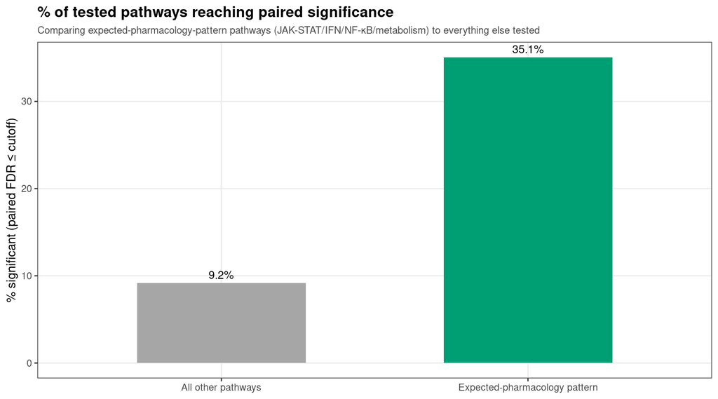

**Interpretation:** a fold enrichment noticeably above 1, with a small Fisher p-value, indicates expected-pharmacology-pattern pathways are hit at a higher rate than the rest of the tested universe — consistent with an on-target and downstream pharmacological effect rather than pathways lighting up at the same background rate as everything else. Note this test pools rows across cell types, so a pathway tested in 18 cell types contributes up to 18 rows; treat the overall p-value as indicative rather than a formally independent-samples test (see Test 2 for a complementary, per-pathway recurrence check that respects cell-type structure more directly).

## Test 2: Cross-cell-type recurrence via Fisher’s method

**Question:** for pathways that turned up as paired-significant in several independent cell types, is that recurrence itself stronger than chance? Each cell type’s paired test is run on a biologically distinct, largely independent population, so seeing the same pathway significant across many of them is a separate piece of evidence from any single cell type’s FDR.

For the top 15 most-recurring paired-significant pathways (ranked by number of cell types in which they reached significance), this combines that pathway’s p-value **from every cell type it was tested in** (whether or not it was individually significant there) using Fisher’s method, then applies a Benjamini-Hochberg correction across the resulting list.

Cross-cell-type recurrence: Fisher’s method combining per-cell-type p-values. P-values below machine precision are floored and shown as ‘< 1e-300’ rather than 0.

| Database | Pathway | Significant in N cell types | Tested in N cell types | -log10(p) | Fisher combined p-value | BH-adjusted q-value |
| --- | --- | --- | --- | --- | --- | --- |
| Hallmark | Interferon Gamma Response | 15 | 18 | 276.0 | 1.08e-276 | 1.61e-275 |
| Hallmark | Interferon Alpha Response | 15 | 18 | 183.4 | 3.73e-184 | 2.80e-183 |
| GO_BP | Adaptive Immune Response | 14 | 17 | 161.4 | 4.25e-162 | 2.13e-161 |
| Reactome | Interferon Signaling | 15 | 18 | 155.7 | 1.90e-156 | 7.11e-156 |
| Hallmark | Oxidative Phosphorylation | 15 | 18 | 121.1 | 8.43e-122 | 2.53e-121 |
| Hallmark | Tnfa Signaling Via Nfkb | 17 | 18 | 118.1 | 7.31e-119 | 1.83e-118 |
| Reactome | Interferon Gamma Signaling | 15 | 18 | 113.7 | 1.82e-114 | 3.91e-114 |
| GO_BP | Aerobic Respiration | 14 | 18 | 98.9 | 1.27e-99 | 2.38e-99 |
| GO_BP | Immune Response Regulating Cell Surface Receptor Signaling Pathway | 15 | 18 | 96.8 | 1.47e-97 | 2.45e-97 |
| GO_BP | Cell Killing | 15 | 18 | 90.2 | 5.76e-91 | 8.64e-91 |
| GO_BP | Adaptive Immune Response Based On Somatic Recombination Of Immune Receptors Built From Immunoglobulin Superfamily Domains | 14 | 18 | 89.2 | 6.10e-90 | 8.32e-90 |
| GO_BP | Leukocyte Mediated Immunity | 15 | 18 | 85.4 | 3.93e-86 | 4.91e-86 |
| GO_BP | Lymphocyte Mediated Immunity | 15 | 18 | 83.4 | 4.46e-84 | 5.15e-84 |
| GO_BP | T Cell Receptor Signaling Pathway | 15 | 18 | 77.3 | 4.78e-78 | 5.12e-78 |
| GO_BP | Alpha Beta T Cell Activation | 15 | 18 | 72.6 | 2.30e-73 | 2.30e-73 |

**Interpretation:** a very small combined p-value for a pathway that recurs across many cell types means that pattern is extremely unlikely to arise if each cell type’s result were an independent random draw — i.e. the recurrence itself, not just any single test, is statistically meaningful. This corroborates Test 1 from a different angle: Test 1 asks whether expected-pharmacology pathways as a category are overrepresented among hits; Test 2 asks whether specific pathways’ repeated appearance across independent cell populations could plausibly be coincidence.

**What these tests do and don’t establish**

Both tests support the claim that this cluster of results is **statistically unlikely to reflect random scatter** across the tested pathway universe. Neither test proves the biological mechanism — that would require leading-edge gene overlap with canonical JAK-STAT target lists, an orthogonal assay (e.g. phospho-STAT flow cytometry), or a permutation test that reruns the full limma+fgsea pipeline under label-shuffled null data. Test 1’s p-value should also be read cautiously since it pools celltype-database-pathway rows rather than treating cell types as fully independent samples.

# External Validation Comparison

**This section is curated, not an unbiased ranking**

**Why only one featured cell type**

An initial version of this section also featured Granulocyte as a secondary myeloid-lineage comparator. It was dropped after review: cell-count diagnostics showed one of four paired subjects contributed fewer than 20 granulocyte cells across both treatment conditions combined, meaning that subject’s contribution to the paired comparison was effectively noise. A follow-up gene-set overlap check also found that the curated pathway list for that population collapsed to roughly half as many *effectively independent* signals as its nominal count, since several of the “agreeing” pathways were near-synonyms sharing most of their genes. Rather than present a comparison with that many caveats attached, this section relies solely on **Macrophage** — a well-powered population across all subjects, and a closer lineage match to the external reference’s myeloid dendritic cells (both are professional antigen-presenting myeloid cells).

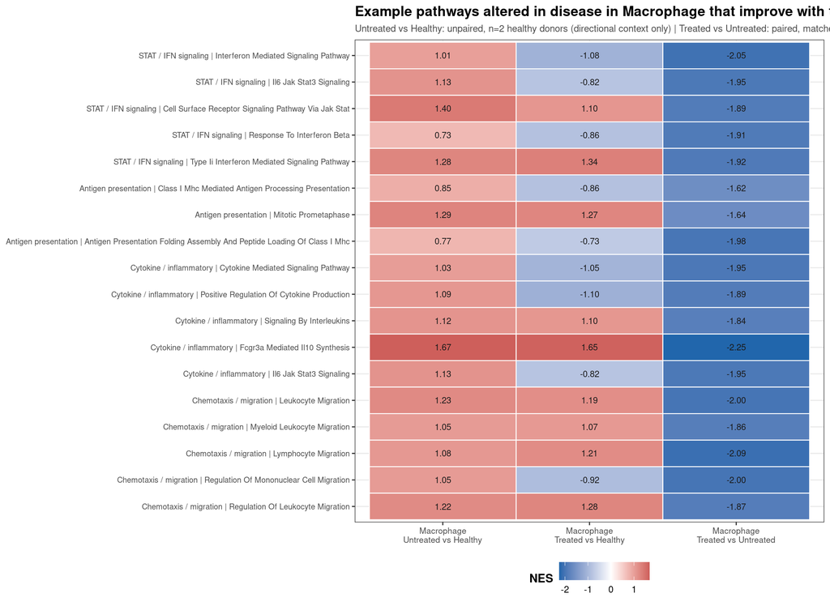

**How to read the three columns**

The three columns here are **not equally reliable**, even though they’re drawn with equal visual weight. `Treated vs Untreated` (right) compares matched subjects within the same dataset and lab workflow — this is the statistically robust result that determined which pathways appear in this section at all (paired-significant, FDR ≤ 0.05). `Untreated vs Healthy` and `Treated vs Healthy` (left, middle) compare against only 2 external healthy donors from a different study, unpaired — a much weaker comparison included purely to suggest a direction, not to make a confident claim on its own. Inconsistent or near-zero values in those two columns do not undermine the paired result on the right; they simply reflect the limits of a 2-donor unpaired reference.

**Featured cell type:** Macrophage. Set `params$featured_celltype` to feature a different one if a more granular myeloid/dendritic-cell annotation becomes available.

# Disease-Associated Pathways and Recovery With Treatment

This section reproduces the two-panel style of an external reference figure, using this dataset’s actual, well-powered starting point:

**Why Treated vs Untreated comes first**

The paired `Treated vs Untreated` comparison is the well-powered, reliable one in this dataset, so it defines which pathways are considered at all. `Untreated vs Healthy` is then used only to ask a follow-up question about those already- significant pathways — does the treatment effect line up with a disease-associated direction — rather than being used to define a separate pathway set of its own.

## Pathways significantly changed by treatment (Treated vs Untreated)

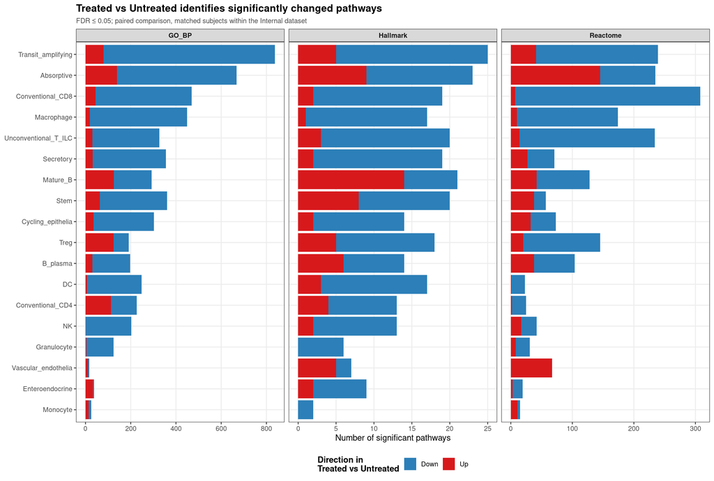

## Are those pathways also disease-associated? (checked against Untreated vs Healthy)

For every pathway significant in `Treated vs Untreated` above, this checks whether `Untreated vs Healthy`’s NES sign (direction only, no significance filter) points in the **opposite** direction from the treatment effect — i.e. the treatment is pushing back against a disease-associated signal, not just moving a pathway for unrelated reasons.

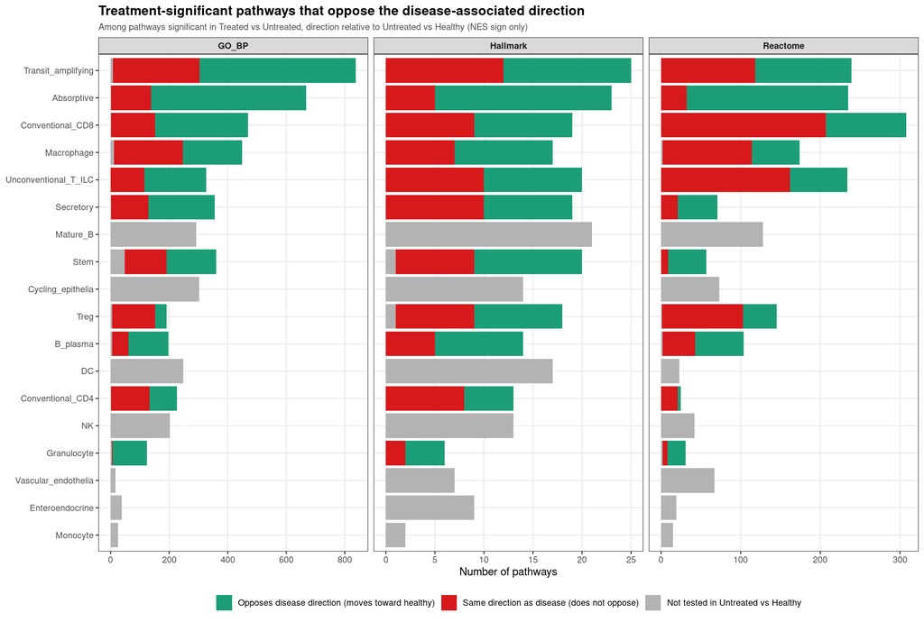

| celltype | Opposes disease direction (moves toward healthy) | Same direction as disease (does not oppose) | Not tested in Untreated vs Healthy | total_tu_significant | pct_opposing_disease |
| --- | --- | --- | --- | --- | --- |
| Granulocyte | 144 | 11 | 6 | 161 | 89.4 |
| Absorptive | 751 | 173 | 2 | 926 | 81.1 |
| B_plasma | 207 | 102 | 7 | 316 | 65.5 |
| Secretory | 285 | 159 | 1 | 445 | 64 |
| Transit_amplifying | 668 | 426 | 8 | 1102 | 60.6 |
| Conventional_CD8 | 428 | 366 | 2 | 796 | 53.8 |
| Stem | 228 | 160 | 49 | 437 | 52.2 |
| Unconventional_T_ILC | 293 | 287 | 0 | 580 | 50.5 |
| Macrophage | 272 | 355 | 13 | 640 | 42.5 |
| Conventional_CD4 | 103 | 161 | 1 | 265 | 38.9 |

[output cut: 8 more lines]

# Explore all significant pathways

| Cell type | Database | Pathway | Interpretation | NES (Untreated vs Healthy) | NES (Treated vs Healthy) | NES (Treated vs Untreated) | Paired FDR |
| --- | --- | --- | --- | --- | --- | --- | --- |
| Absorptive | Reactome | Translation | Disease-low, restored by treatment | -3.73 | -3.68 | 3.44 | 4.55e-52 |
| Absorptive | GO_BP | Ribonucleoprotein Complex Biogenesis | Disease-low, restored by treatment | -2.29 | -2.2 | 3.1 | 2.72e-47 |
| Absorptive | Reactome | Rrna Processing | Disease-low, restored by treatment | -3.08 | -2.97 | 3.47 | 3.36e-43 |
| B_plasma | Reactome | Eukaryotic Translation Elongation | Disease-low, restored by treatment | -3.56 | -3.44 | 3.54 | 4.119999999999999e-40 |
| B_plasma | Reactome | Response Of Eif2ak4 Gcn2 To Amino Acid Deficiency | Disease-low, restored by treatment | -3.44 | -3.33 | 3.5 | 2.42e-39 |
| Absorptive | GO_BP | Ribosome Biogenesis | Disease-low, restored by treatment | -2.33 | -2.2 | 3.17 | 5.56e-39 |
| B_plasma | Reactome | Selenoamino Acid Metabolism | Disease-low, restored by treatment | -3.54 | -3.41 | 3.48 | 1.34e-38 |
| Absorptive | Hallmark | Interferon Gamma Response | Disease-low, further decreased | -0.96 | -1.28 | -3.38 | 9.589999999999999e-37 |
| Absorptive | Reactome | Eukaryotic Translation Elongation | Disease-low, restored by treatment | -3.56 | -3.53 | 3.56 | 1.37e-36 |
| B_plasma | Reactome | Eukaryotic Translation Initiation | Disease-low, restored by treatment | -3.49 | -3.38 | 3.42 | 2.62e-36 |

[output cut: 10102 more lines]

# Focused biological programs

A curated set of pathway keyword groups, showing the single strongest paired-significant pathway per cell type × database × program.

[interactive chart not shown]

# Notes